#### Roll No. 85

# Boston Housing Price Prediction using Deep Neural Networks

This notebook implements a deep neural network to predict housing prices using the Boston Housing dataset.

## Problem Statement:

**Linear regression by using Deep Neural network:** Implement Boston housing price prediction problem by Linear regression using Deep Neural network. Use Boston House price prediction dataset.

## Dataset Description

The Boston Housing dataset contains information about various features of houses in Boston suburbs and their prices. Each record has 13 features:

| Feature | Description |
| --- | --- |
| CRIM | Per capita crime rate by town |
| ZN | Proportion of residential land zoned for lots over 25,000 sq.ft |
| INDUS | Proportion of non-retail business acres per town |
| CHAS | Charles River dummy variable (1 if tract bounds river; 0 otherwise) |
| NOX | Nitric oxides concentration (parts per 10 million) |
| RM | Average number of rooms per dwelling |
| AGE | Proportion of owner-occupied units built prior to 1940 |
| DIS | Weighted distances to five Boston employment centers |
| RAD | Index of accessibility to radial highways |
| TAX | Full-value property-tax rate per $10,000 |
| PTRATIO | Pupil-teacher ratio by town |
| B | 1000(Bk - 0.63)^2 where Bk is the proportion of blacks by town |
| LSTAT | % lower status of the population |

**Target Variable**: MEDV (Median value of owner-occupied homes in $1000s)

## Import Required Libraries

```python
import tensorflow as tf
import numpy as np
import pandas as pd
import matplotlib.pyplot as plt
from sklearn.model_selection import train_test_split
from sklearn.preprocessing import StandardScaler
import warnings
warnings.filterwarnings('ignore')

# Set random seed for reproducibility
np.random.seed(42)
tf.random.set_seed(42)
```

## Data Loading and Preprocessing

We'll load the Boston Housing dataset and preprocess it by:

1. Loading from the original source
2. Normalizing features using StandardScaler
3. Splitting into train, validation, and test sets

```python
def load_boston_housing_data():
    """Load and preprocess the Boston Housing dataset from its original source."""
    data_url = "http://lib.stat.cmu.edu/datasets/boston"
    raw_df = pd.read_csv(data_url, sep="\s+", skiprows=22, header=None)
    data = np.hstack([raw_df.values[::2, :], raw_df.values[1::2, :2]])
    target = raw_df.values[1::2, 2]

    # Normalize features and target
    scaler_X = StandardScaler()
    scaler_y = StandardScaler()

    X = scaler_X.fit_transform(data)
    y = scaler_y.fit_transform(target.reshape(-1, 1))

    return X, y, scaler_y

# Load and preprocess data
X, y, scaler_y = load_boston_housing_data()

# Split the data
X_train, X_test, y_train, y_test = train_test_split(X, y, test_size=0.2, random_state=42)
X_train, X_val, y_train, y_val = train_test_split(X_train, y_train, test_size=0.2, random_state=42)

print(f"Training set shape: {X_train.shape}")
print(f"Validation set shape: {X_val.shape}")
print(f"Test set shape: {X_test.shape}")
```

```
Training set shape: (323, 13)
Validation set shape: (81, 13)
Test set shape: (102, 13)
```

## Model Architecture

We'll create a deep neural network with the following features:

- Batch normalization for training stability
- Dropout layers for regularization
- L2 regularization on dense layers
- Multiple hidden layers with decreasing units

```python
def create_model():
    """Creates an improved neural network model for housing price prediction."""
    model = tf.keras.Sequential([
        # Input layer
        tf.keras.layers.Input(shape=(13,)),
        tf.keras.layers.BatchNormalization(),

        # First hidden layer
        tf.keras.layers.Dense(128, kernel_regularizer=tf.keras.regularizers.l2(0.01)),
        tf.keras.layers.BatchNormalization(),
        tf.keras.layers.Activation('relu'),
        tf.keras.layers.Dropout(0.3),

        # Second hidden layer
        tf.keras.layers.Dense(64, kernel_regularizer=tf.keras.regularizers.l2(0.01)),
        tf.keras.layers.BatchNormalization(),
        tf.keras.layers.Activation('relu'),
        tf.keras.layers.Dropout(0.2),

        # Third hidden layer
        tf.keras.layers.Dense(32, kernel_regularizer=tf.keras.regularizers.l2(0.01)),
        tf.keras.layers.BatchNormalization(),
        tf.keras.layers.Activation('relu'),
        tf.keras.layers.Dropout(0.1),

        # Output layer
        tf.keras.layers.Dense(1)
    ])

    return model

# Create and compile model
model = create_model()
model.compile(
    optimizer=tf.keras.optimizers.Adam(learning_rate=0.001),
    loss='mse',
    metrics=['mae']
)

model.summary()
```

```
Model: "sequential"
```

```
┏━━━━━━━━━━━━━━━━━━━━━━━━━━━━━━━━━┳━━━━━━━━━━━━━━━━━━━━━━━━┳━━━━━━━━━━━━━━━┓
┃ Layer (type)                    ┃ Output Shape           ┃       Param # ┃
┡━━━━━━━━━━━━━━━━━━━━━━━━━━━━━━━━━╇━━━━━━━━━━━━━━━━━━━━━━━━╇━━━━━━━━━━━━━━━┩
│ batch_normalization             │ (None, 13)             │            52 │
│ (BatchNormalization)            │                        │               │
├─────────────────────────────────┼────────────────────────┼───────────────┤
│ dense (Dense)                   │ (None, 128)            │         1,792 │
├─────────────────────────────────┼────────────────────────┼───────────────┤
│ batch_normalization_1           │ (None, 128)            │           512 │
│ (BatchNormalization)            │                        │               │
├─────────────────────────────────┼────────────────────────┼───────────────┤
│ activation (Activation)         │ (None, 128)            │             0 │
├─────────────────────────────────┼────────────────────────┼───────────────┤
│ dropout (Dropout)               │ (None, 128)            │             0 │
├─────────────────────────────────┼────────────────────────┼───────────────┤
│ dense_1 (Dense)                 │ (None, 64)             │         8,256 │
├─────────────────────────────────┼────────────────────────┼───────────────┤
│ batch_normalization_2           │ (None, 64)             │           256 │
│ (BatchNormalization)            │                        │               │
├─────────────────────────────────┼────────────────────────┼───────────────┤
│ activation_1 (Activation)       │ (None, 64)             │             0 │
├─────────────────────────────────┼────────────────────────┼───────────────┤
│ dropout_1 (Dropout)             │ (None, 64)             │             0 │
├─────────────────────────────────┼────────────────────────┼───────────────┤
│ dense_2 (Dense)                 │ (None, 32)             │         2,080 │
├─────────────────────────────────┼────────────────────────┼───────────────┤
│ batch_normalization_3           │ (None, 32)             │           128 │
│ (BatchNormalization)            │                        │               │
├─────────────────────────────────┼────────────────────────┼───────────────┤
│ activation_2 (Activation)       │ (None, 32)             │             0 │
├─────────────────────────────────┼────────────────────────┼───────────────┤
│ dropout_2 (Dropout)             │ (None, 32)             │             0 │
├─────────────────────────────────┼────────────────────────┼───────────────┤
│ dense_3 (Dense)                 │ (None, 1)              │            33 │
└─────────────────────────────────┴────────────────────────┴───────────────┘
```

```
 Total params: 13,109 (51.21 KB)
```

```
 Trainable params: 12,635 (49.36 KB)
```

```
 Non-trainable params: 474 (1.85 KB)
```

## Model Training

We'll train the model with:

- Early stopping to prevent overfitting
- Learning rate reduction on plateau
- Batch size of 32
- Maximum 200 epochs

```python
# Create TensorFlow datasets
batch_size = 32
train_dataset = tf.data.Dataset.from_tensor_slices((X_train, y_train)).shuffle(len(X_train)).batch(batch_size)
val_dataset = tf.data.Dataset.from_tensor_slices((X_val, y_val)).batch(batch_size)
test_dataset = tf.data.Dataset.from_tensor_slices((X_test, y_test)).batch(batch_size)

# Callbacks
callbacks = [
    tf.keras.callbacks.EarlyStopping(
        monitor='val_loss',
        patience=20,
        restore_best_weights=True,
        verbose=1
    ),
    tf.keras.callbacks.ReduceLROnPlateau(
        monitor='val_loss',
        factor=0.2,
        patience=10,
        min_lr=0.00001,
        verbose=1
    )
]

# Train the model
history = model.fit(
    train_dataset,
    epochs=200,
    validation_data=val_dataset,
    callbacks=callbacks,
    verbose=1
)
```

```
11/11 ━━━━━━━━━━━━━━━━━━━━ 3s 29ms/step - loss: 3.1960 - mae: 0.9936 - val_loss: 2.1415 - val_mae: 0.5745 - learning_rate: 0.0010
11/11 ━━━━━━━━━━━━━━━━━━━━ 0s 6ms/step - loss: 2.3969 - mae: 0.7262 - val_loss: 2.0091 - val_mae: 0.4895 - learning_rate: 0.0010
11/11 ━━━━━━━━━━━━━━━━━━━━ 0s 6ms/step - loss: 2.2680 - mae: 0.6547 - val_loss: 1.9687 - val_mae: 0.4882 - learning_rate: 0.0010
11/11 ━━━━━━━━━━━━━━━━━━━━ 0s 6ms/step - loss: 2.1208 - mae: 0.6026 - val_loss: 1.9584 - val_mae: 0.4955 - learning_rate: 0.0010
11/11 ━━━━━━━━━━━━━━━━━━━━ 0s 6ms/step - loss: 2.0749 - mae: 0.5831 - val_loss: 1.9126 - val_mae: 0.4739 - learning_rate: 0.0010
11/11 ━━━━━━━━━━━━━━━━━━━━ 0s 6ms/step - loss: 2.0347 - mae: 0.5900 - val_loss: 1.8501 - val_mae: 0.4306 - learning_rate: 0.0010
11/11 ━━━━━━━━━━━━━━━━━━━━ 0s 6ms/step - loss: 1.9803 - mae: 0.5599 - val_loss: 1.8086 - val_mae: 0.4067 - learning_rate: 0.0010
11/11 ━━━━━━━━━━━━━━━━━━━━ 0s 5ms/step - loss: 1.8943 - mae: 0.5262 - val_loss: 1.7908 - val_mae: 0.4041 - learning_rate: 0.0010
11/11 ━━━━━━━━━━━━━━━━━━━━ 0s 6ms/step - loss: 1.9317 - mae: 0.5423 - val_loss: 1.7564 - val_mae: 0.3880 - learning_rate: 0.0010
11/11 ━━━━━━━━━━━━━━━━━━━━ 0s 6ms/step - loss: 1.8327 - mae: 0.4987 - val_loss: 1.7306 - val_mae: 0.3839 - learning_rate: 0.0010
11/11 ━━━━━━━━━━━━━━━━━━━━ 0s 6ms/step - loss: 1.8388 - mae: 0.5116 - val_loss: 1.6995 - val_mae: 0.3708 - learning_rate: 0.0010
11/11 ━━━━━━━━━━━━━━━━━━━━ 0s 6ms/step - loss: 1.8051 - mae: 0.4862 - val_loss: 1.6749 - val_mae: 0.3605 - learning_rate: 0.0010
11/11 ━━━━━━━━━━━━━━━━━━━━ 0s 5ms/step - loss: 1.7097 - mae: 0.4546 - val_loss: 1.6787 - val_mae: 0.3772 - learning_rate: 0.0010
11/11 ━━━━━━━━━━━━━━━━━━━━ 0s 7ms/step - loss: 1.7142 - mae: 0.4711 - val_loss: 1.6723 - val_mae: 0.3786 - learning_rate: 0.0010
11/11 ━━━━━━━━━━━━━━━━━━━━ 0s 6ms/step - loss: 1.7922 - mae: 0.4979 - val_loss: 1.6435 - val_mae: 0.3637 - learning_rate: 0.0010
11/11 ━━━━━━━━━━━━━━━━━━━━ 0s 6ms/step - loss: 1.7015 - mae: 0.4752 - val_loss: 1.6208 - val_mae: 0.3574 - learning_rate: 0.0010
11/11 ━━━━━━━━━━━━━━━━━━━━ 0s 6ms/step - loss: 1.7061 - mae: 0.4890 - val_loss: 1.5971 - val_mae: 0.3479 - learning_rate: 0.0010
11/11 ━━━━━━━━━━━━━━━━━━━━ 0s 6ms/step - loss: 1.5937 - mae: 0.4275 - val_loss: 1.5785 - val_mae: 0.3432 - learning_rate: 0.0010
11/11 ━━━━━━━━━━━━━━━━━━━━ 0s 6ms/step - loss: 1.6672 - mae: 0.4572 - val_loss: 1.5681 - val_mae: 0.3466 - learning_rate: 0.0010
11/11 ━━━━━━━━━━━━━━━━━━━━ 0s 6ms/step - loss: 1.7356 - mae: 0.5148 - val_loss: 1.5570 - val_mae: 0.3466 - learning_rate: 0.0010
11/11 ━━━━━━━━━━━━━━━━━━━━ 0s 5ms/step - loss: 1.6087 - mae: 0.4402 - val_loss: 1.5597 - val_mae: 0.3626 - learning_rate: 0.0010
11/11 ━━━━━━━━━━━━━━━━━━━━ 0s 6ms/step - loss: 1.5445 - mae: 0.4115 - val_loss: 1.5517 - val_mae: 0.3711 - learning_rate: 0.0010
11/11 ━━━━━━━━━━━━━━━━━━━━ 0s 6ms/step - loss: 1.5759 - mae: 0.4440 - val_loss: 1.5206 - val_mae: 0.3515 - learning_rate: 0.0010
11/11 ━━━━━━━━━━━━━━━━━━━━ 0s 5ms/step - loss: 1.5719 - mae: 0.4551 - val_loss: 1.5237 - val_mae: 0.3660 - learning_rate: 0.0010
11/11 ━━━━━━━━━━━━━━━━━━━━ 0s 6ms/step - loss: 1.6418 - mae: 0.4696 - val_loss: 1.4925 - val_mae: 0.3453 - learning_rate: 0.0010
11/11 ━━━━━━━━━━━━━━━━━━━━ 0s 6ms/step - loss: 1.5205 - mae: 0.4195 - val_loss: 1.4655 - val_mae: 0.3230 - learning_rate: 0.0010
11/11 ━━━━━━━━━━━━━━━━━━━━ 0s 6ms/step - loss: 1.4805 - mae: 0.4120 - val_loss: 1.4476 - val_mae: 0.3204 - learning_rate: 0.0010
11/11 ━━━━━━━━━━━━━━━━━━━━ 0s 7ms/step - loss: 1.5387 - mae: 0.4459 - val_loss: 1.4375 - val_mae: 0.3323 - learning_rate: 0.0010
11/11 ━━━━━━━━━━━━━━━━━━━━ 0s 7ms/step - loss: 1.5282 - mae: 0.4361 - val_loss: 1.4257 - val_mae: 0.3360 - learning_rate: 0.0010
11/11 ━━━━━━━━━━━━━━━━━━━━ 0s 6ms/step - loss: 1.5302 - mae: 0.4620 - val_loss: 1.4027 - val_mae: 0.3220 - learning_rate: 0.0010
11/11 ━━━━━━━━━━━━━━━━━━━━ 0s 6ms/step - loss: 1.4396 - mae: 0.4234 - val_loss: 1.3931 - val_mae: 0.3268 - learning_rate: 0.0010
11/11 ━━━━━━━━━━━━━━━━━━━━ 0s 6ms/step - loss: 1.4925 - mae: 0.4417 - val_loss: 1.3897 - val_mae: 0.3296 - learning_rate: 0.0010
11/11 ━━━━━━━━━━━━━━━━━━━━ 0s 5ms/step - loss: 1.3563 - mae: 0.3867 - val_loss: 1.3888 - val_mae: 0.3435 - learning_rate: 0.0010
11/11 ━━━━━━━━━━━━━━━━━━━━ 0s 6ms/step - loss: 1.4029 - mae: 0.4069 - val_loss: 1.3797 - val_mae: 0.3455 - learning_rate: 0.0010
11/11 ━━━━━━━━━━━━━━━━━━━━ 0s 7ms/step - loss: 1.4157 - mae: 0.4076 - val_loss: 1.3580 - val_mae: 0.3322 - learning_rate: 0.0010
11/11 ━━━━━━━━━━━━━━━━━━━━ 0s 6ms/step - loss: 1.3848 - mae: 0.4091 - val_loss: 1.3357 - val_mae: 0.3179 - learning_rate: 0.0010
11/11 ━━━━━━━━━━━━━━━━━━━━ 0s 6ms/step - loss: 1.3807 - mae: 0.4082 - val_loss: 1.3303 - val_mae: 0.3222 - learning_rate: 0.0010
11/11 ━━━━━━━━━━━━━━━━━━━━ 0s 6ms/step - loss: 1.3754 - mae: 0.4110 - val_loss: 1.3156 - val_mae: 0.3105 - learning_rate: 0.0010
11/11 ━━━━━━━━━━━━━━━━━━━━ 0s 6ms/step - loss: 1.4017 - mae: 0.4488 - val_loss: 1.3011 - val_mae: 0.3043 - learning_rate: 0.0010
11/11 ━━━━━━━━━━━━━━━━━━━━ 0s 5ms/step - loss: 1.4008 - mae: 0.4361 - val_loss: 1.2837 - val_mae: 0.3004 - learning_rate: 0.0010
```

[output cut: 146 more lines]

```
11/11 ━━━━━━━━━━━━━━━━━━━━ 0s 4ms/step - loss: 0.5322 - mae: 0.3285 - val_loss: 0.5499 - val_mae: 0.3229 - learning_rate: 0.0010
11/11 ━━━━━━━━━━━━━━━━━━━━ 0s 5ms/step - loss: 0.5333 - mae: 0.3288 - val_loss: 0.5659 - val_mae: 0.3331 - learning_rate: 0.0010
11/11 ━━━━━━━━━━━━━━━━━━━━ 0s 5ms/step - loss: 0.5345 - mae: 0.3185 - val_loss: 0.5585 - val_mae: 0.3295 - learning_rate: 0.0010
11/11 ━━━━━━━━━━━━━━━━━━━━ 0s 5ms/step - loss: 0.5202 - mae: 0.3268 - val_loss: 0.5329 - val_mae: 0.3242 - learning_rate: 0.0010
11/11 ━━━━━━━━━━━━━━━━━━━━ 0s 5ms/step - loss: 0.5336 - mae: 0.3397 - val_loss: 0.5217 - val_mae: 0.3232 - learning_rate: 0.0010
11/11 ━━━━━━━━━━━━━━━━━━━━ 0s 5ms/step - loss: 0.5174 - mae: 0.3367 - val_loss: 0.5066 - val_mae: 0.3065 - learning_rate: 0.0010
11/11 ━━━━━━━━━━━━━━━━━━━━ 0s 5ms/step - loss: 0.4966 - mae: 0.3099 - val_loss: 0.5159 - val_mae: 0.3027 - learning_rate: 0.0010
11/11 ━━━━━━━━━━━━━━━━━━━━ 0s 5ms/step - loss: 0.6035 - mae: 0.3993 - val_loss: 0.5237 - val_mae: 0.3075 - learning_rate: 0.0010
11/11 ━━━━━━━━━━━━━━━━━━━━ 0s 5ms/step - loss: 0.5402 - mae: 0.3367 - val_loss: 0.5264 - val_mae: 0.3215 - learning_rate: 0.0010
11/11 ━━━━━━━━━━━━━━━━━━━━ 0s 4ms/step - loss: 0.5120 - mae: 0.3256 - val_loss: 0.5373 - val_mae: 0.3379 - learning_rate: 0.0010
11/11 ━━━━━━━━━━━━━━━━━━━━ 0s 4ms/step - loss: 0.4954 - mae: 0.3094 - val_loss: 0.5170 - val_mae: 0.3211 - learning_rate: 0.0010
11/11 ━━━━━━━━━━━━━━━━━━━━ 0s 5ms/step - loss: 0.4610 - mae: 0.2842 - val_loss: 0.4957 - val_mae: 0.3040 - learning_rate: 0.0010
11/11 ━━━━━━━━━━━━━━━━━━━━ 0s 5ms/step - loss: 0.4602 - mae: 0.2873 - val_loss: 0.4898 - val_mae: 0.2993 - learning_rate: 0.0010
11/11 ━━━━━━━━━━━━━━━━━━━━ 0s 5ms/step - loss: 0.4728 - mae: 0.2941 - val_loss: 0.4912 - val_mae: 0.3051 - learning_rate: 0.0010
Restoring model weights from the end of the best epoch: 199.
```

## Training History Visualization

Let's visualize how the model performed during training:

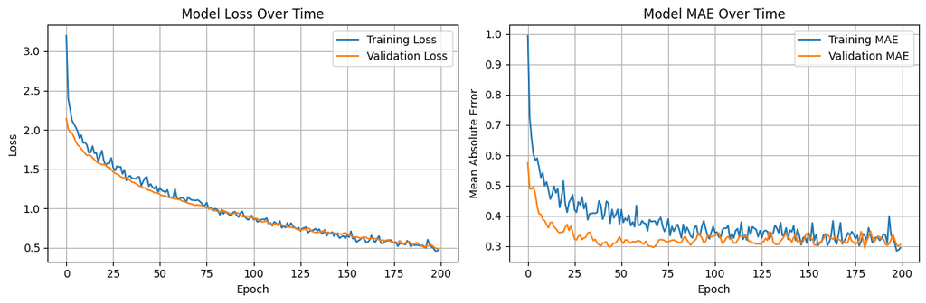

```python
plt.figure(figsize=(12, 4))

# Loss plot
plt.subplot(1, 2, 1)
plt.plot(history.history['loss'], label='Training Loss')
plt.plot(history.history['val_loss'], label='Validation Loss')
plt.title('Model Loss Over Time')
plt.xlabel('Epoch')
plt.ylabel('Loss')
plt.legend()
plt.grid(True)

# MAE plot
plt.subplot(1, 2, 2)
plt.plot(history.history['mae'], label='Training MAE')
plt.plot(history.history['val_mae'], label='Validation MAE')
plt.title('Model MAE Over Time')
plt.xlabel('Epoch')
plt.ylabel('Mean Absolute Error')
plt.legend()
plt.grid(True)

plt.tight_layout()
plt.show()
```

## Model Evaluation and Predictions

Let's evaluate the model on the test set and make some sample predictions:

```python
# Evaluate on test set
test_results = model.evaluate(test_dataset, verbose=0)
print(f"Test Mean Absolute Error (normalized): {test_results[1]:.4f}")

# Make predictions
test_predictions = model.predict(X_test)

# Convert predictions back to original scale
test_predictions_original = scaler_y.inverse_transform(test_predictions)
test_actual_original = scaler_y.inverse_transform(y_test)

# Calculate metrics in original scale
mae_original = np.mean(np.abs(test_predictions_original - test_actual_original))
mse = np.mean((test_predictions_original - test_actual_original) ** 2)
rmse = np.sqrt(mse)
r2 = 1 - (np.sum((test_actual_original - test_predictions_original) ** 2) /
          np.sum((test_actual_original - np.mean(test_actual_original)) ** 2))

print(f"\nTest Mean Absolute Error: ${mae_original:.2f}k")
print(f"Root Mean Square Error: ${rmse:.2f}k")
print(f"R-squared Score: {r2:.4f}")

# Show sample predictions
print("\nSample Predictions vs Actual Values (in $1000s):")
for pred, actual in zip(test_predictions_original[:5], test_actual_original[:5]):
    print(f"Predicted: ${pred[0]:.2f}k, Actual: ${actual[0]:.2f}k")
```

```
Test Mean Absolute Error (normalized): 0.2430
4/4 ━━━━━━━━━━━━━━━━━━━━ 0s 36ms/step

Test Mean Absolute Error: $2.23k
Root Mean Square Error: $3.28k
R-squared Score: 0.8536

Sample Predictions vs Actual Values (in $1000s):
Predicted: $26.56k, Actual: $23.60k
Predicted: $34.87k, Actual: $32.40k
Predicted: $16.19k, Actual: $13.60k
Predicted: $22.31k, Actual: $22.80k
Predicted: $16.38k, Actual: $16.10k
```

## Prediction vs Actual Plot

Let's visualize how well our predictions match the actual values:

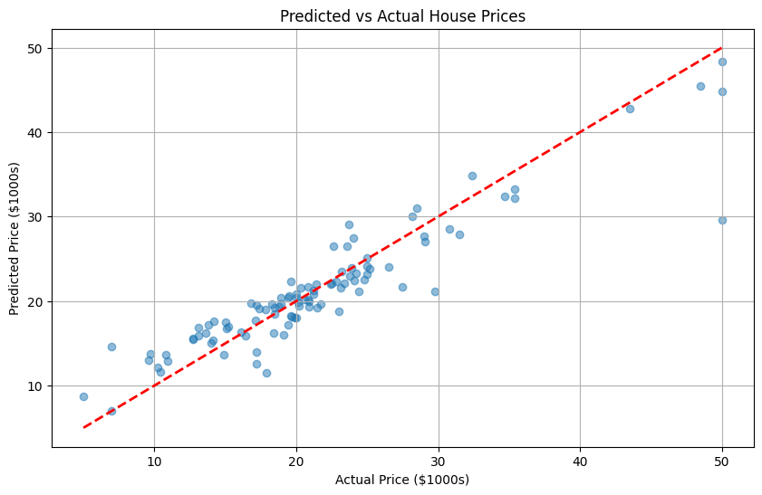

```python
plt.figure(figsize=(10, 6))
plt.scatter(test_actual_original, test_predictions_original, alpha=0.5)
plt.plot([test_actual_original.min(), test_actual_original.max()],
         [test_actual_original.min(), test_actual_original.max()],
         'r--', lw=2)
plt.xlabel('Actual Price ($1000s)')
plt.ylabel('Predicted Price ($1000s)')
plt.title('Predicted vs Actual House Prices')
plt.grid(True)
plt.show()
```